## Predictive Model for Stock Movement - Case Study

### Background: This case study is a continuation of ML1 case study. Decision Tree, Support Vector Machines and Neural Networks are used to predict the stock direction.

#### Machine Learning Algorithms are very useful to predict movement of stock-either to predict price or direction. In Spite of a lot of uncertainty, the well trained models can help to develop successful trading strategies. In this case study, we consider one of the leading global IT companies-Infosys and predict its next day movement using various ML algorithms.

### Objective: To predict closing price direction of Infosys stock on day t+1 relative to day t .

### Libraries used:

| Library | Application |
| --- | --- |
| quantmod | To download stock data |
| roll | To calculate rolling standard deviation |
| ggplot2 | To plot graphs |
| ROCR | To calculate area under ROC Curve |
| caret | To get Confusion Matrix |
| rpart | To implement Decision Tree algorithm |
| e1071 | To implement SVM algorithm |
| neuralnet | To implement Neural Network algorithm |
| dplyr | To handle data |

### Yahoo Finance Tickers Used

| Ticker Name | Description |
| --- | --- |
| INFY | Infosys Limited is an Indian multinational information technology company that provides business consulting, information technology and outsourcing services. |
| NASDAQ | The Nasdaq Stock Market is an American stock exchange based in New York City |

```r
infy<-data.frame(getSymbols("INFY.NS", src="yahoo" , from = '2020-12-01', to = '2022-06-30', auto.assign = FALSE))
infy$Date<-as.Date(row.names(infy))
infy<-subset(infy,select = c(Date,INFY.NS.Open,INFY.NS.High,INFY.NS.Low,INFY.NS.Close))
names(infy)<-c('Date','Open','High','Low','Close')
row.names(infy)<-NULL
head(infy)
```

```
        Date    Open    High     Low   Close
1 2020-12-01 1105.05 1140.25 1105.05 1137.85
2 2020-12-02 1134.00 1147.45 1121.00 1140.90
3 2020-12-03 1147.00 1147.00 1122.70 1126.45
4 2020-12-04 1125.00 1137.00 1115.00 1134.65
5 2020-12-07 1147.30 1153.00 1136.00 1143.50
6 2020-12-08 1145.00 1167.00 1145.00 1153.35
```

### Table of derived variables:

| Column Name | Description |
| --- | --- |
| Returns | percent change |
| Direction | Returns>0, Direction +ve & Returns<0, Direction -ve |
| CloseToOpen | Ratio of close/open |
| HighToLow | Ratio of high/low |
| Std_deviation | Rolling standard deviation(infy returns) for past one month |
| Direction_next | Shifting direction column |

### Deriving Variables

```r
infy$Returns<-round((infy$Close - lag(infy$Close))/lag(infy$Close)*100,2)
infy$Direction<-ifelse(infy$Returns>0,1,0)
infy$CloseToOpen <- infy$Close/infy$Open
infy$HighToLow <- infy$High/infy$Low
infy$Std_deviation <- roll::roll_sd(infy$Returns, 21)
infy$Direction_next <- lead(infy$Direction,1)
head(infy)
```

```
        Date    Open    High     Low   Close Returns Direction CloseToOpen
1 2020-12-01 1105.05 1140.25 1105.05 1137.85      NA        NA   1.0296818
2 2020-12-02 1134.00 1147.45 1121.00 1140.90    0.27         1   1.0060847
3 2020-12-03 1147.00 1147.00 1122.70 1126.45   -1.27         0   0.9820837
4 2020-12-04 1125.00 1137.00 1115.00 1134.65    0.73         1   1.0085778
5 2020-12-07 1147.30 1153.00 1136.00 1143.50    0.78         1   0.9966878
6 2020-12-08 1145.00 1167.00 1145.00 1153.35    0.86         1   1.0072926
  HighToLow Std_deviation Direction_next
1  1.031854            NA              1
2  1.023595            NA              0
3  1.021644            NA              1
4  1.019731            NA              1
5  1.014965            NA              1
6  1.019214            NA              1
```

### Visualizing Direction

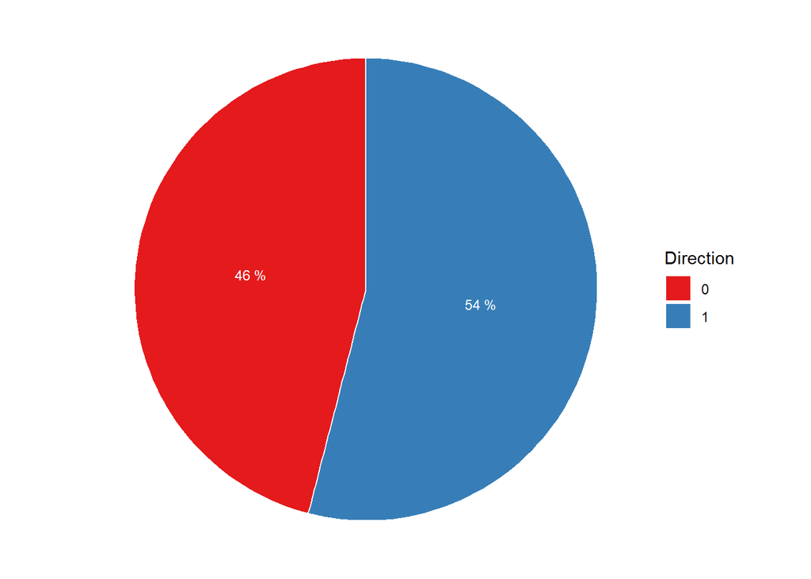

```r
dir_df<-data.frame(table(infy$Direction))
names(dir_df)<-c("Direction","Count")
dir_df <- dir_df %>%
  arrange(desc(Direction)) %>%
  mutate(prop = round(Count / sum(dir_df$Count) *100),0) %>%
  mutate(ypos = cumsum(prop)- 0.5*prop )

ggplot(dir_df, aes(x="", y=prop, fill=Direction)) +
  geom_bar(stat="identity", width=1, color="white") +
  coord_polar("y", start=0) +
  theme_void() +
  geom_text(aes(y = ypos, label = paste(prop,"%")), color = "white", size=3) +
  scale_fill_brewer(palette="Set1")
```

### Bar chart for derived variables grouped by Direction_next

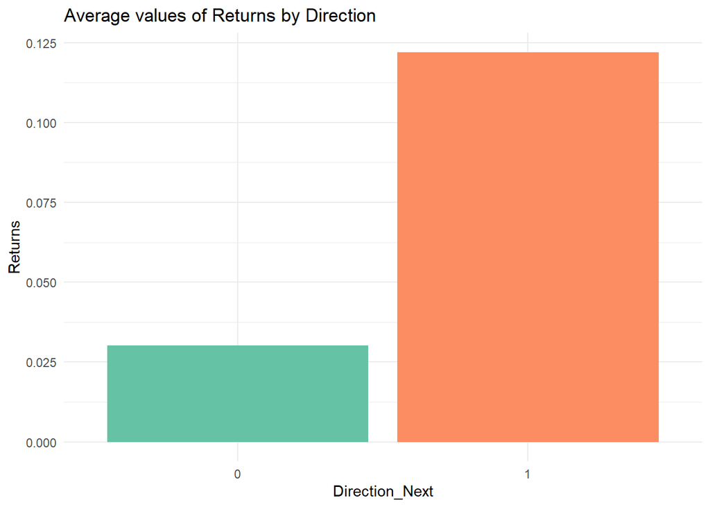

```r
ret_dirnext<-aggregate(Returns~Direction_next,data = infy,FUN=mean)
ret_h2l<-aggregate(HighToLow~Direction_next,data = infy,FUN=mean)
ret_c2o<-aggregate(CloseToOpen~Direction_next,data = infy,FUN=mean)


ggplot(ret_dirnext, aes(x=as.factor(Direction_next), y=Returns, fill=as.factor(Direction_next))) +
  geom_bar(stat="identity")+theme_minimal()+scale_fill_brewer(palette="Set2")+
  theme(legend.position="none")+ggtitle("Average values of Returns by Direction")+xlab("Direction_Next")
```

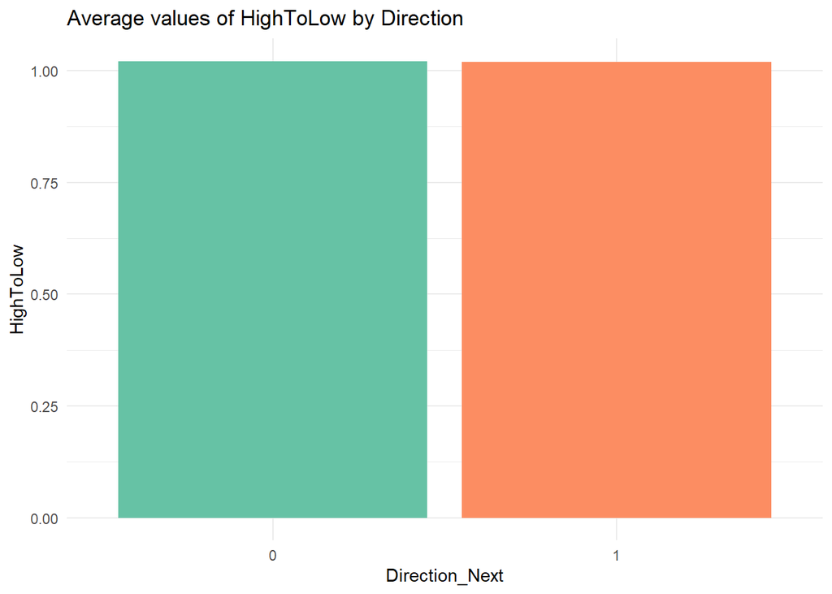

```r
ggplot(ret_h2l, aes(x=as.factor(Direction_next), y=HighToLow, fill=as.factor(Direction_next))) +
  geom_bar(stat="identity")+theme_minimal()+scale_fill_brewer(palette="Set2")+
  theme(legend.position="none")+ggtitle("Average values of HighToLow by Direction")+xlab("Direction_Next")
```

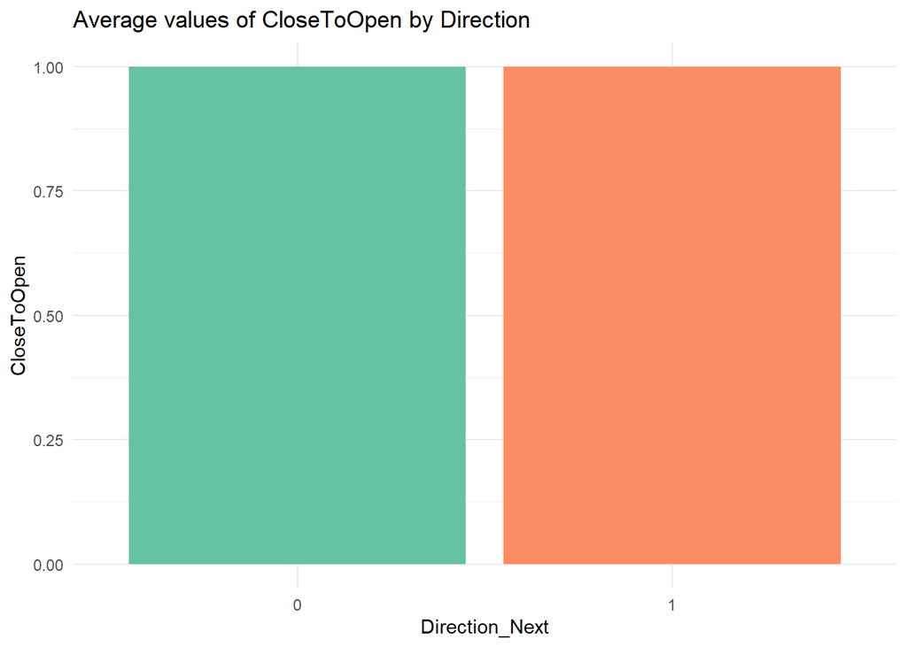

```r
ggplot(ret_c2o, aes(x=as.factor(Direction_next), y=CloseToOpen, fill=as.factor(Direction_next))) +
  geom_bar(stat="identity")+theme_minimal()+scale_fill_brewer(palette="Set2")+
  theme(legend.position="none")+ggtitle("Average values of CloseToOpen by Direction")+xlab("Direction_Next")
```

### Downloading NASDAQ data and calculating returns

```r
nasdaq  <- data.frame(getSymbols("^IXIC", src="yahoo" , from = "2020-11-30", to = "2022-06-30", auto.assign = FALSE))

nasdaq$Date<-as.Date(row.names(nasdaq))
nasdaq<-subset(nasdaq,select = c(Date,IXIC.Open,IXIC.High,IXIC.Low,IXIC.Close))
names(nasdaq)<-c('Date','Open','High','Low','Close')
row.names(nasdaq)<-NULL
nasdaq$Returns_ndq<-round((nasdaq$Close - lag(nasdaq$Close))/lag(nasdaq$Close)*100,2)
head(nasdaq)
```

```
        Date     Open     High      Low    Close Returns_ndq
1 2020-11-30 12224.25 12244.65 12027.16 12198.74          NA
2 2020-12-01 12313.36 12405.79 12263.93 12355.11        1.28
3 2020-12-02 12285.75 12360.06 12217.35 12349.37       -0.05
4 2020-12-03 12369.26 12439.02 12356.99 12377.18        0.23
5 2020-12-04 12399.32 12464.23 12376.44 12464.23        0.70
6 2020-12-07 12461.00 12536.23 12460.55 12519.95        0.45
```

### Merging Infy and Nasdaq data

```r
finaldata<-merge(infy,subset(nasdaq,select = c(Date,Returns_ndq)),by="Date",all=T)
```

### Dropping nulls

```r
finaldata_rm<-na.omit(finaldata)
```

### Model 1. Decision Tree

#### Building Model

```r
finaldata_rm$Direction_next<-as.factor(finaldata_rm$Direction_next)

index<-createDataPartition(finaldata_rm$Direction_next,p=0.7,list=FALSE)
traindata<-finaldata_rm[index,]
testdata<-finaldata_rm[-index,]
threshold<-0.54

library(rpart)

rpart_inf<-rpart(Direction_next ~  Returns + CloseToOpen + HighToLow + Std_deviation + Returns_ndq,
                 data=traindata, method="class",parms=list(split="information"))
```

#### Predicting probabilities

```r
testdata$preddt<-predict(rpart_inf,testdata)[,2]
```

#### Generating Confusion Matrix

```r
testdata$predYdt<-ifelse(testdata$preddt>threshold,1,0)
testdata$predYdt<-as.factor(testdata$predYdt)

confusionMatrix(testdata$predYdt,testdata$Direction_next,positive = "1")
```

```
Confusion Matrix and Statistics

          Reference
Prediction  0  1
         0 27 20
         1 22 37

               Accuracy : 0.6038
                 95% CI : (0.5041, 0.6975)
    No Information Rate : 0.5377
    P-Value [Acc > NIR] : 0.1023

                  Kappa : 0.2007

 Mcnemar's Test P-Value : 0.8774

            Sensitivity : 0.6491
            Specificity : 0.5510
         Pos Pred Value : 0.6271
         Neg Pred Value : 0.5745
             Prevalence : 0.5377
         Detection Rate : 0.3491
   Detection Prevalence : 0.5566
      Balanced Accuracy : 0.6001

       'Positive' Class : 1
```

#### Computing AUC value for ROC curve

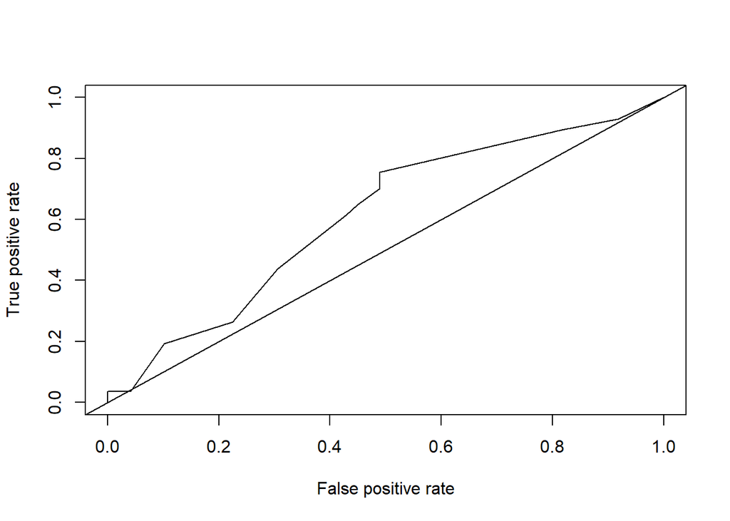

```r
preddt2<-ROCR::prediction(testdata$preddt,testdata$Direction_next)
perfdt2<-performance(preddt2,"tpr","fpr")
plot(perfdt2)
abline(0,1)
```

```r
aucdt2<-performance(preddt2,"auc")
aucdt2@y.values
```

```
[[1]]
[1] 0.6109918
```

#### Plotting tree

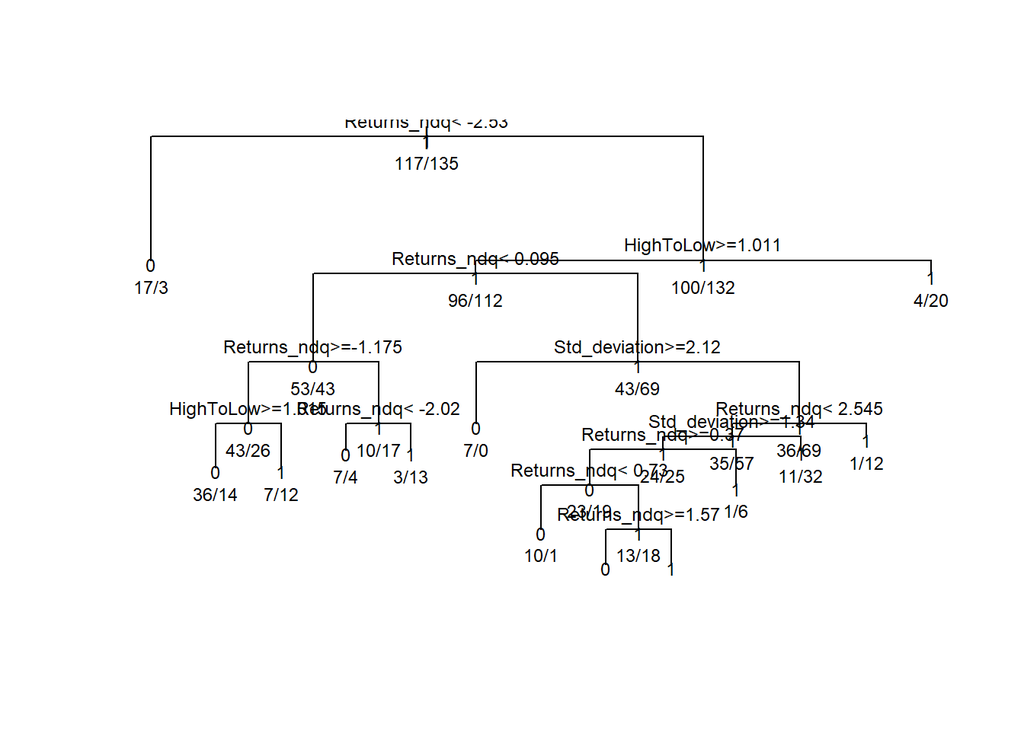

```r
# par(mfrow=c(1,1),xpd=NA)
plot(rpart_inf)
text(rpart_inf,splits=T,use.n=T,all=T,cex=0.75)
```

### Comment: The overall model accuracy is 60%,sensitivity is 65% and area under the ROC curve is 61%

### Model 2. Support Vector Machines

#### Building Model

```r
svm<-svm(Direction_next ~  Returns + CloseToOpen + HighToLow + Std_deviation + Returns_ndq,
                 data=traindata,type="C",probability=TRUE,kernel="linear")

svm
```

```
Call:
svm(formula = Direction_next ~ Returns + CloseToOpen + HighToLow +
    Std_deviation + Returns_ndq, data = traindata, type = "C", probability = TRUE,
    kernel = "linear")


Parameters:
   SVM-Type:  C-classification
 SVM-Kernel:  linear
       cost:  1

Number of Support Vectors:  211
```

#### Predicting probabilities

```r
pred1<-predict(svm,testdata,probability=TRUE)

testdata$predprobsvm<-attr(pred1,"probabilities")[,1]
```

#### Generating Confusion Matrix

```r
testdata$predYsvm<-ifelse(testdata$predprob>threshold,1,0)
testdata$predYsvm<-as.factor(testdata$predYsvm)

confusionMatrix(testdata$predYsvm,testdata$Direction_next,positive = "1")
```

```
Confusion Matrix and Statistics

          Reference
Prediction  0  1
         0 24 21
         1 25 36

               Accuracy : 0.566
                 95% CI : (0.4663, 0.662)
    No Information Rate : 0.5377
    P-Value [Acc > NIR] : 0.3139

                  Kappa : 0.1221

 Mcnemar's Test P-Value : 0.6583

            Sensitivity : 0.6316
            Specificity : 0.4898
         Pos Pred Value : 0.5902
         Neg Pred Value : 0.5333
             Prevalence : 0.5377
         Detection Rate : 0.3396
   Detection Prevalence : 0.5755
      Balanced Accuracy : 0.5607

       'Positive' Class : 1
```

#### Computing AUC value for ROC curve

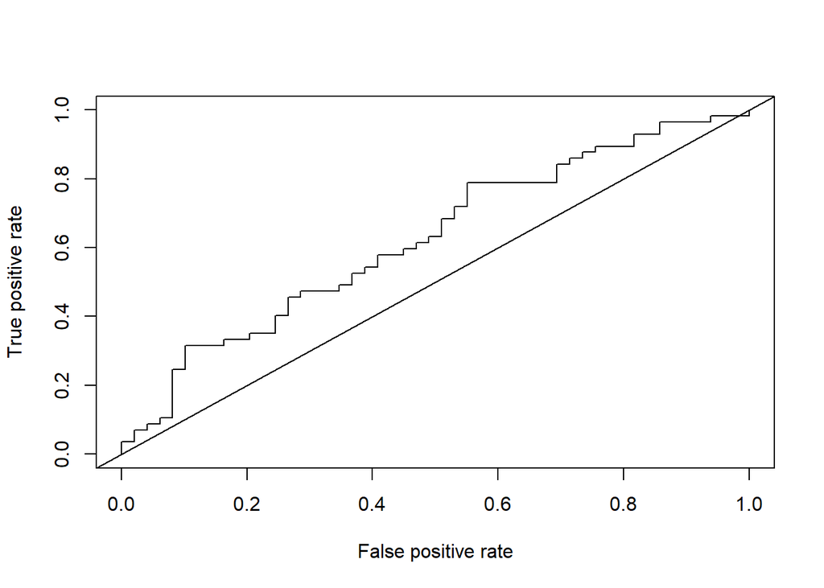

```r
predsvm<-ROCR::prediction(testdata$predprobsvm,testdata$Direction_next)
perfsvm<-performance(predsvm,"tpr","fpr")
plot(perfsvm)
abline(0,1)
```

```r
aucsvm<-performance(predsvm,"auc")
aucsvm@y.values
```

```
[[1]]
[1] 0.6237021
```

### Comment: The overall model accuracy is 57%,sensitivity is 63% and area under the ROC curve is 62%

### Model 3. Neural Networks

#### Building Model

```r
normalize <- function(x) {
  return ((x - min(x)) / (max(x) - min(x)))
}

traindata$Returns<-normalize(traindata$Returns)
traindata$CloseToOpen<-normalize(traindata$CloseToOpen)
traindata$HighToLow<-normalize(traindata$HighToLow)
traindata$Std_deviation<-normalize(traindata$Std_deviation)
traindata$Returns_ndq<-normalize(traindata$Returns_ndq)

library(neuralnet)

nn_bank <- neuralnet(Direction_next ~  Returns + CloseToOpen + HighToLow +
                    Std_deviation + Returns_ndq,data=traindata,
                     hidden=2,err.fct="ce",linear.output=FALSE)
```

#### Plotting neural network

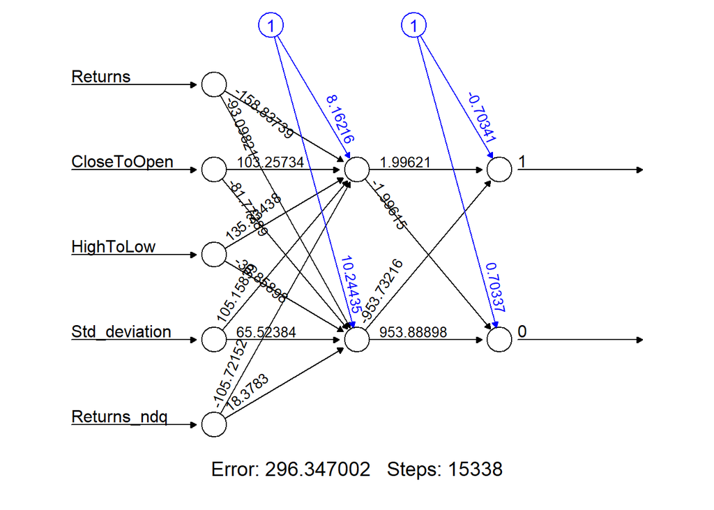

```r
plot(nn_bank,rep = "best")
```

#### Predicting probabilities

```r
testdata$prednn<-predict(nn_bank,testdata)[,2]
```

#### Generating Confusion Matrix

```r
testdata$predYnn<-ifelse(testdata$prednn>threshold,1,0)
testdata$predYnn<-as.factor(testdata$predYnn)

confusionMatrix(testdata$predYnn,testdata$Direction_next,positive = "1")
```

```
Confusion Matrix and Statistics

          Reference
Prediction  0  1
         0 29 24
         1 20 33

               Accuracy : 0.5849
                 95% CI : (0.4851, 0.6798)
    No Information Rate : 0.5377
    P-Value [Acc > NIR] : 0.1905

                  Kappa : 0.1698

 Mcnemar's Test P-Value : 0.6511

            Sensitivity : 0.5789
            Specificity : 0.5918
         Pos Pred Value : 0.6226
         Neg Pred Value : 0.5472
             Prevalence : 0.5377
         Detection Rate : 0.3113
   Detection Prevalence : 0.5000
      Balanced Accuracy : 0.5854

       'Positive' Class : 1
```

#### Computing AUC value for ROC curve

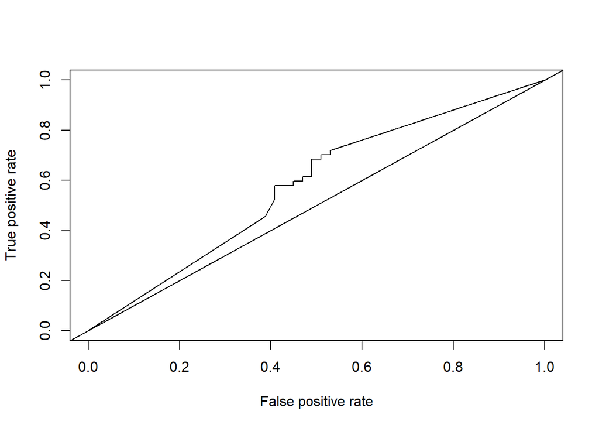

```r
prednn<-ROCR::prediction(testdata$prednn,testdata$Direction_next)
perfnn<-performance(prednn,"tpr","fpr")
plot(perfnn)
abline(0,1)
```

```r
aucnn<-performance(prednn,"auc")
aucnn@y.values
```

```
[[1]]
[1] 0.5785893
```